# Sales Forecast. Linear Regression and ARIMA

Iryna G Duda

### 1.Preparing Data

```r
dataset <- read.csv("Data.csv")
headTail(dataset, 3)
```

|  | Yr | Mo_No | Date | AvgSold | AvgShipTo | AvgWeekly_Inv | TotalUniqSoldTos | TotalUniqShipTos | TotalInv |
| --- | --- | --- | --- | --- | --- | --- | --- | --- | --- |
| 1 | 2020 | 6 | 6/1/2020 | 199 | 290 | 167630.74 | 3585 | 5237 | 3017353.39 |
| 2 | 2020 | 5 | 5/1/2020 | 173 | 236 | 130332.09 | 3821 | 5206 | 2867306.08 |
| 3 | 2020 | 4 | 4/1/2020 | 144 | 180 | 114283.33 | 3189 | 3971 | 2514233.16 |
| ... | ... | ... | NA | ... | ... | ... | ... | ... | ... |
| 51 | 2016 | 4 | 4/1/2016 | 203 | 245 | 114009.7 | 4473 | 5403 | 2508213.51 |
| 52 | 2016 | 3 | 3/1/2016 | 219 | 265 | 121933.76 | 5264 | 6362 | 2926410.14 |
| 53 | 2016 | 2 | 2/1/2016 | 227 | 273 | 130722.16 | 4775 | 5753 | 2745165.31 |
| 54 | 2016 | 1 | 1/1/2016 | 192 | 232 | 111036.55 | 4241 | 5112 | 2442804.13 |

```r
dataset <- data.frame(dataset)
attach(dataset)
dataset$Yr <- as.factor(Yr)
dataset$Mo_No <- as.factor(Mo_No)
dataset$Date <- as.Date(dataset$Date, format = "%m/%d/%Y")  #format='%B %d %Y'
str(dataset)
```

```
## 'data.frame':    54 obs. of  9 variables:
##  $ Yr              : Factor w/ 5 levels "2016","2017",..: 5 5 5 5 5 5 4 4 4 4 ...
##  $ Mo_No           : Factor w/ 12 levels "1","2","3","4",..: 6 5 4 3 2 1 12 11 10 9 ...
##  $ Date            : Date, format: "2020-06-01" ...
##  $ AvgSold         : int  199 173 144 160 177 215 180 174 193 203 ...
##  $ AvgShipTo       : int  290 236 180 228 261 318 268 260 290 301 ...
##  $ AvgWeekly_Inv   : num  167631 130332 114283 141889 163166 ...
##  $ TotalUniqSoldTos: int  3585 3821 3189 4014 4426 4750 4337 4199 5408 4471 ...
##  $ TotalUniqShipTos: int  5237 5206 3971 5721 6530 6999 6445 6256 8133 6630 ...
##  $ TotalInv        : num  3017353 2867306 2514233 3547220 4079161 ...
```

```r
dataset$AvgWeekly_Inv <- as.numeric(AvgWeekly_Inv)
dataset$TotalInv <- as.numeric(TotalInv)
dataset <- dataset[order(dataset$Date, dataset$Mo_No), ]
attach(dataset)
des(dataset)
```

```
##
##  No. of observations =  54
##   Variable         Class           Description
## 1 Yr               factor
## 2 Mo_No            factor
## 3 Date             Date
## 4 AvgSold          integer
## 5 AvgShipTo        integer
## 6 AvgWeekly_Inv    numeric
## 7 TotalUniqSoldTos integer
## 8 TotalUniqShipTos integer
## 9 TotalInv         numeric
```

```r
str(dataset)
```

```
## 'data.frame':    54 obs. of  9 variables:
##  $ Yr              : Factor w/ 5 levels "2016","2017",..: 1 1 1 1 1 1 1 1 1 1 ...
##  $ Mo_No           : Factor w/ 12 levels "1","2","3","4",..: 1 2 3 4 5 6 7 8 9 10 ...
##  $ Date            : Date, format: "2016-01-01" ...
##  $ AvgSold         : int  192 227 219 203 205 223 211 204 218 205 ...
##  $ AvgShipTo       : int  232 273 265 245 252 274 261 251 271 257 ...
##  $ AvgWeekly_Inv   : num  111037 130722 121934 114010 118883 ...
##  $ TotalUniqSoldTos: int  4241 4775 5264 4473 4310 4911 4434 4909 4586 4310 ...
##  $ TotalUniqShipTos: int  5112 5753 6362 5403 5295 6046 5487 6042 5696 5417 ...
##  $ TotalInv        : num  2442804 2745165 2926410 2508214 2496541 ...
```

### 2. Exploring Data

Data values after February 2020 will be excluded from the dataset.

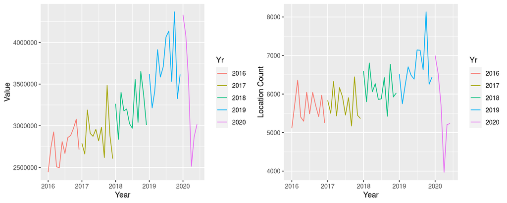

```r
p2 <- ggplot(dataset, aes(x = Date, y = TotalInv, col = Yr, shape = Yr)) +
    geom_line(size = 0.5) + xlab("Year") + ylab("Value")

p3 <- ggplot(dataset, aes(x = Date, y = TotalUniqShipTos, col = Yr,
    shape = Yr, show.legend = FALSE)) + geom_line(size = 0.5) +
    xlab("Year") + ylab("Location Count")
grid.arrange(p2, p3, ncol = 2)
```

Relationship between Location count (as TotalUniqShipTos) and Sales (TotalInv) will be explored further because these variables significantly correlated.

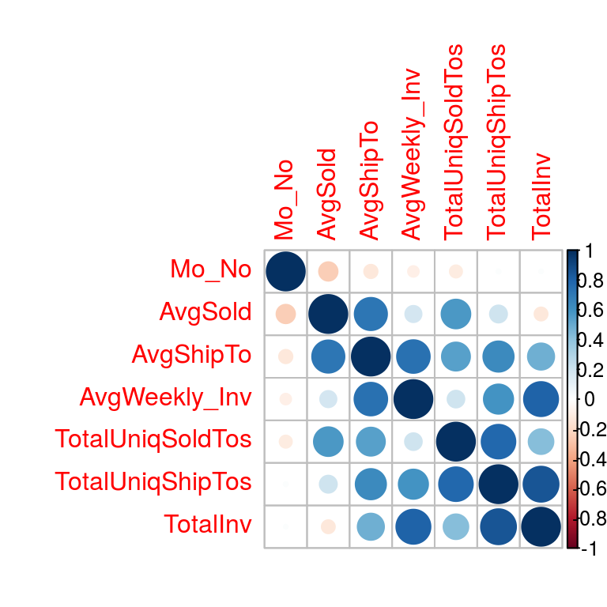

```r
# Exploring correlations
library(corrplot)
cor_data <- dataset[, -3]
cor_data$Mo_No <- as.numeric(cor_data$Mo_No)
# cor(cor_data[,2:8])#0.85022403 for shiptos total invoice
# relationships
corrplot(cor(cor_data[, 2:8]), method = "circle")
```

### 3. Exploring the relationships, cleaning dataset from the outliers

```r
mod1 <- lm(dataset$TotalInv ~ dataset$TotalUniqShipTos)
summary(mod1)
```

```
##
## Call:
## lm(formula = dataset$TotalInv ~ dataset$TotalUniqShipTos)
##
## Residuals:
##     Min      1Q  Median      3Q     Max
## -465466 -180788  -25607  168626  591146
##
## Coefficients:
##                            Estimate Std. Error t value
## (Intercept)              -516293.23  318521.05  -1.621
## dataset$TotalUniqShipTos     614.30      52.74  11.647
##                          Pr(>|t|)
## (Intercept)                 0.111
## dataset$TotalUniqShipTos 4.16e-16 ***
## ---
## Signif. codes:
## 0 '***' 0.001 '**' 0.01 '*' 0.05 '.' 0.1 ' ' 1
##
## Residual standard error: 257100 on 52 degrees of freedom
## Multiple R-squared:  0.7229, Adjusted R-squared:  0.7176
## F-statistic: 135.6 on 1 and 52 DF,  p-value: 4.155e-16
```

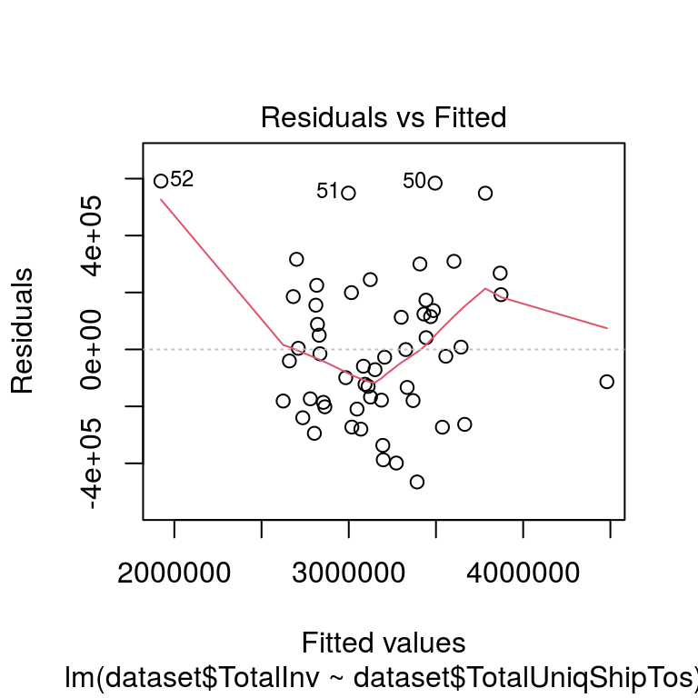

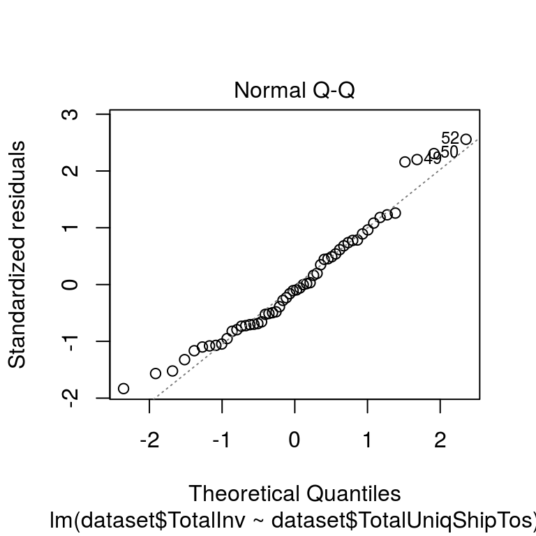

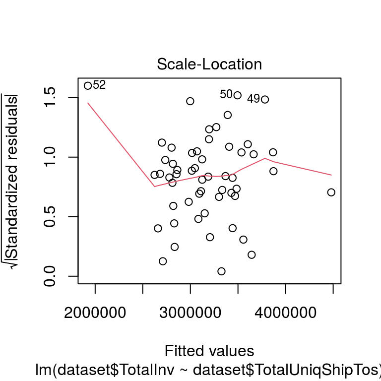

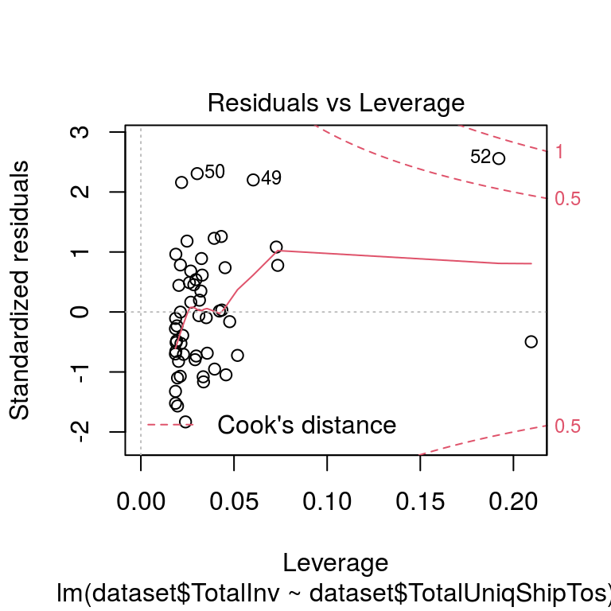

```r
plot(mod1)
```

```r
dataset2 <- dataset[c(-49, -50, -52), ]
head(dataset2)
```

|  | Yr | Mo_No | Date | AvgSold | AvgShipTo | AvgWeekly_Inv | TotalUniqSoldTos | TotalUniqShipTos | TotalInv |
| --- | --- | --- | --- | --- | --- | --- | --- | --- | --- |
| 54 | 2016 | 1 | 2016-01-01 | 192 | 232 | 111036.6 | 4241 | 5112 | 2442804 |
| 53 | 2016 | 2 | 2016-02-01 | 227 | 273 | 130722.2 | 4775 | 5753 | 2745165 |
| 52 | 2016 | 3 | 2016-03-01 | 219 | 265 | 121933.8 | 5264 | 6362 | 2926410 |
| 51 | 2016 | 4 | 2016-04-01 | 203 | 245 | 114009.7 | 4473 | 5403 | 2508214 |
| 50 | 2016 | 5 | 2016-05-01 | 205 | 252 | 118882.9 | 4310 | 5295 | 2496541 |
| 49 | 2016 | 6 | 2016-06-01 | 223 | 274 | 127731.1 | 4911 | 6046 | 2810085 |

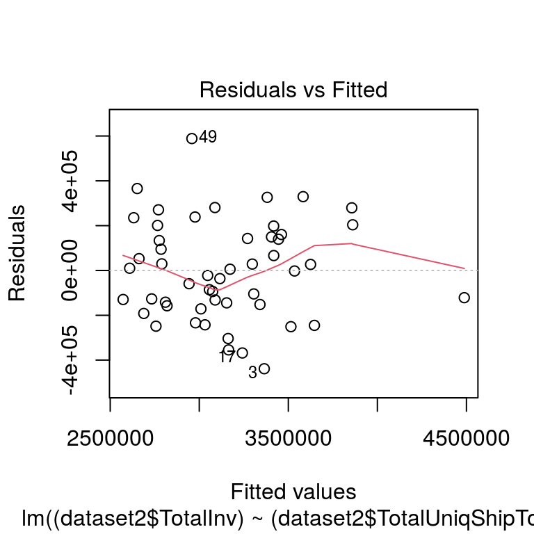

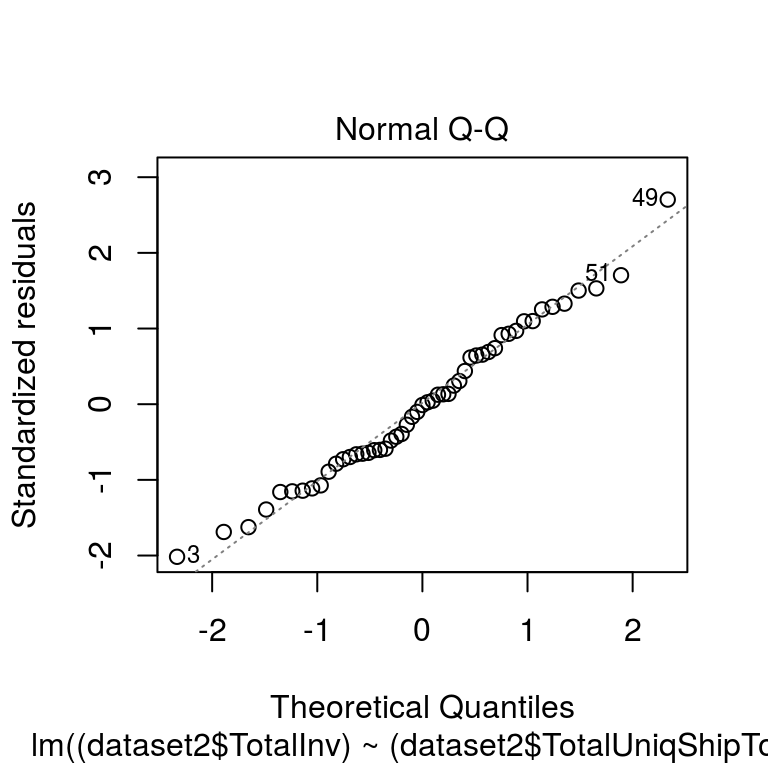

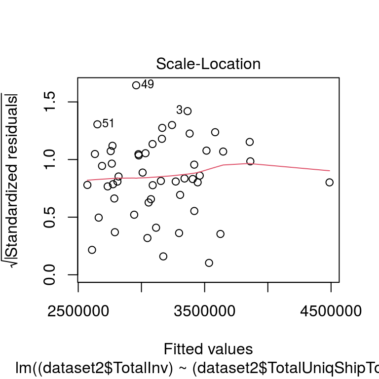

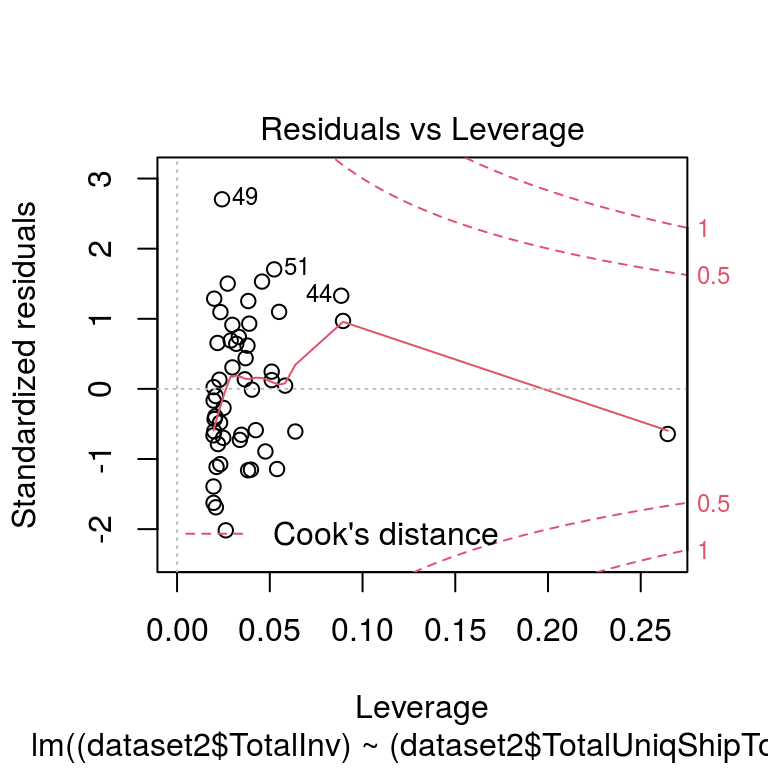

```r
mod2 <- lm((dataset2$TotalInv) ~ (dataset2$TotalUniqShipTos))
plot(mod2)
```

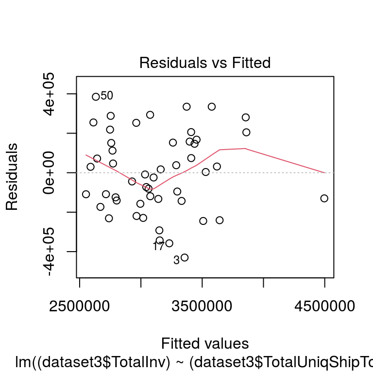

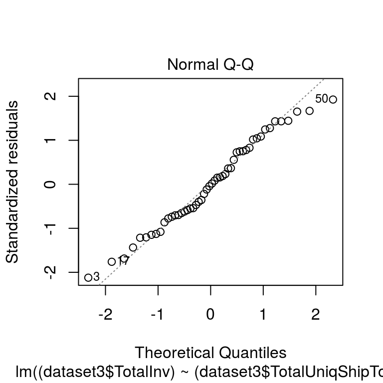

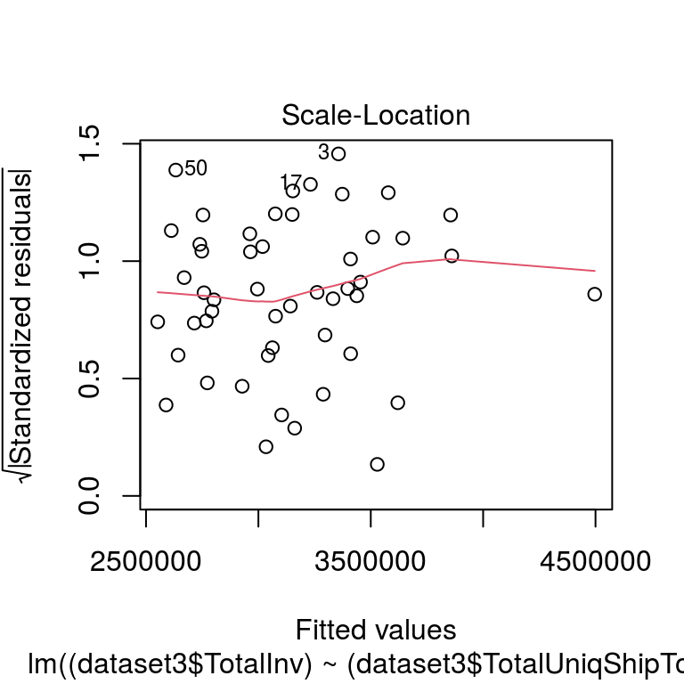

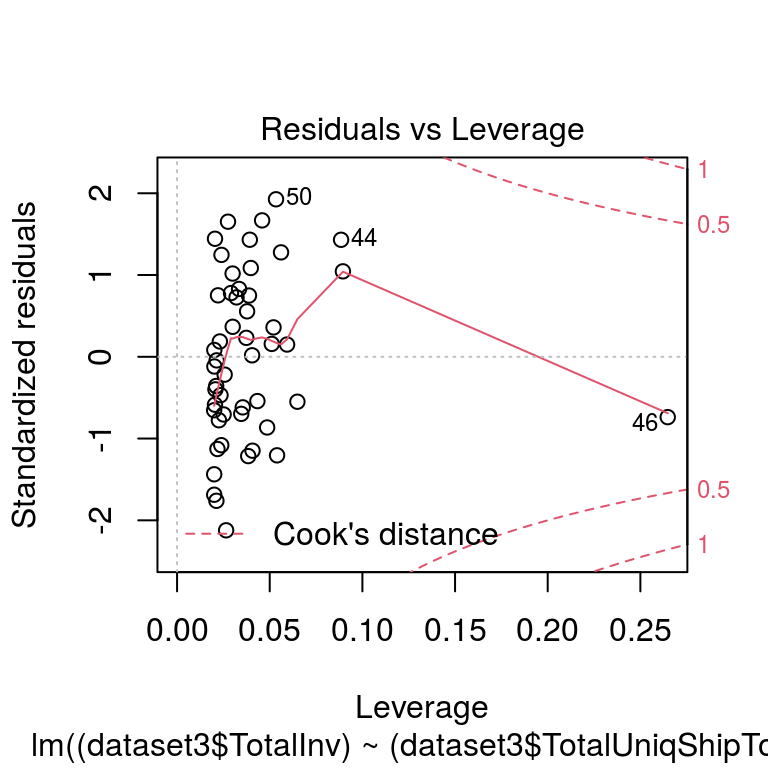

```r
dataset3 <- dataset2[c(-49), ]
mod3 <- lm((dataset3$TotalInv) ~ (dataset3$TotalUniqShipTos))
plot(mod3)
```

```r
# dataset4<-dataset3[c(-50),]
attach(dataset3)
```

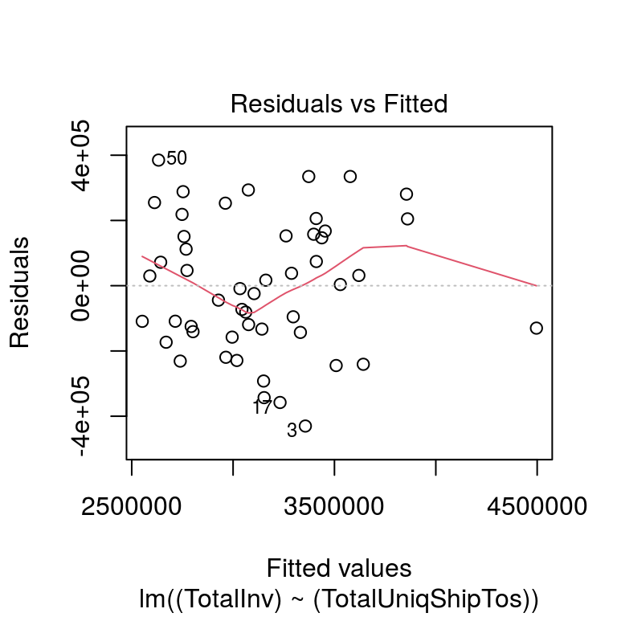

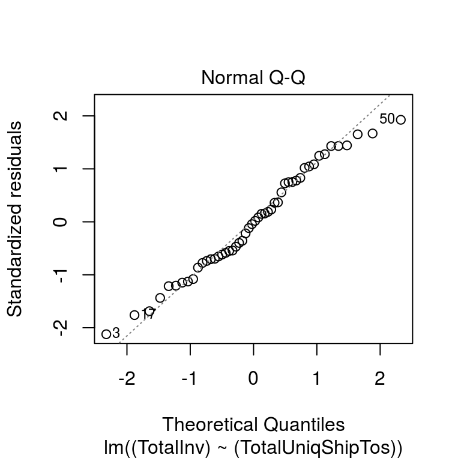

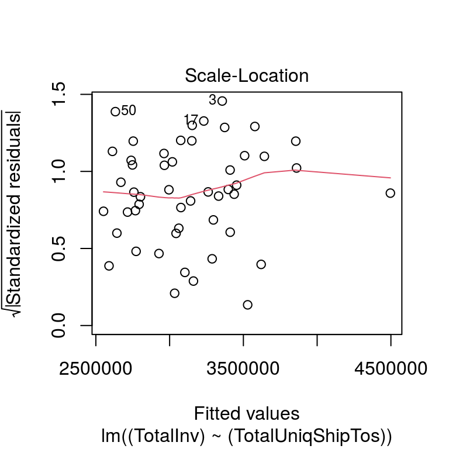

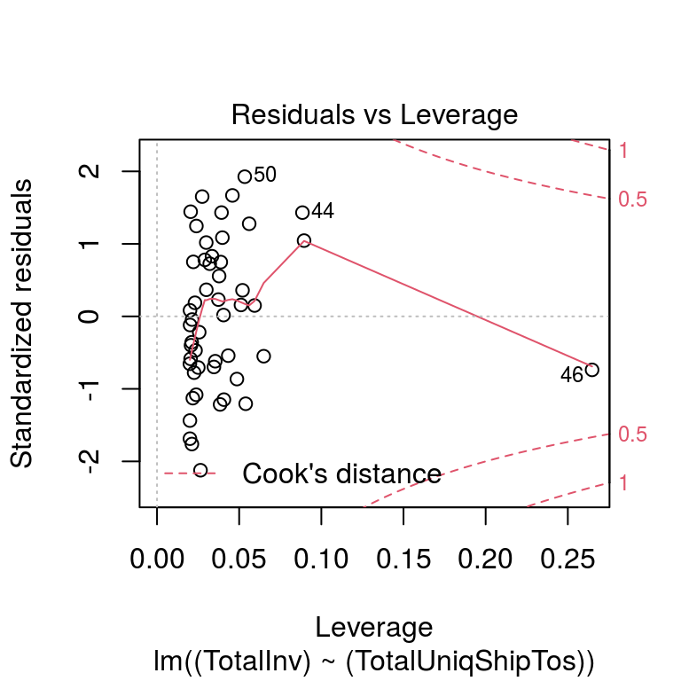

```r
mod4 <- lm((TotalInv) ~ (TotalUniqShipTos))
plot(mod4)
```

### 4. Evaluating the Linear Regression model

Count of Shipto Locations explain 78% of the total variance of a dependent (response) Sales variable.  
22% of the variance remains unexplained though.

```r
summary(mod4)  #R adj = 7845
```

```
##
## Call:
## lm(formula = (TotalInv) ~ (TotalUniqShipTos))
##
## Residuals:
##     Min      1Q  Median      3Q     Max
## -430095 -138858   -2635  156486  384947
##
## Coefficients:
##                    Estimate Std. Error t value Pr(>|t|)
## (Intercept)      -738352.23  290648.44   -2.54   0.0144 *
## TotalUniqShipTos     643.64      48.05   13.39   <2e-16 ***
## ---
## Signif. codes:
## 0 '***' 0.001 '**' 0.01 '*' 0.05 '.' 0.1 ' ' 1
##
## Residual standard error: 205400 on 48 degrees of freedom
## Multiple R-squared:  0.7889, Adjusted R-squared:  0.7845
## F-statistic: 179.4 on 1 and 48 DF,  p-value: < 2.2e-16
```

```r
AIC(mod4)  # 1369.131
```

```
## [1] 1369.131
```

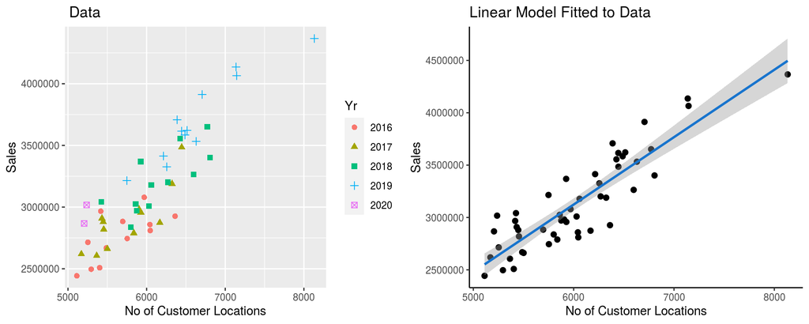

```r
p1 <- ggplot(dataset3, aes(x = TotalUniqShipTos, y = TotalInv,
    col = Yr, shape = Yr)) + geom_point(size = 2) + xlab("No of Customer Locations") +
    ylab("Sales") + ggtitle(" Data")

p4 <- ggplot(dataset3, aes(x = TotalUniqShipTos, y = TotalInv)) +
    geom_point(size = 2) + xlab("No of Customer Locations") +
    ylab("Sales") + stat_smooth(method = "lm", col = "dodgerblue3") +
    theme(panel.background = element_rect(fill = "white"), axis.line.x = element_line(),
        axis.line.y = element_line()) + ggtitle("Linear Model Fitted to Data")

grid.arrange(p1, p4, ncol = 2)
```

### Step 1. Create Training and Test data

```r
set.seed(100)
trainingRowIndex <- sample(1:nrow(dataset2), 0.8 * nrow(dataset2))  # row indices for training data
trainingData <- dataset2[trainingRowIndex, ]  # model training data
testData <- dataset2[-trainingRowIndex, ]  # test data
```

### Step 2: Develop the model on the training data and use it to predict Sales on test data

```r
# Build the model on training data -
lmMod <- lm(TotalInv ~ TotalUniqShipTos, data = trainingData)  # build the model
Pred <- predict(lmMod, testData)
```

### Step 3: Review diagnostic measures

```r
summary(lmMod)  # model summary, R adj 77.56
```

```
##
## Call:
## lm(formula = TotalInv ~ TotalUniqShipTos, data = trainingData)
##
## Residuals:
##     Min      1Q  Median      3Q     Max
## -362138 -153872  -15081  163482  580227
##
## Coefficients:
##                   Estimate Std. Error t value Pr(>|t|)
## (Intercept)      -645683.5   327493.4  -1.972    0.056 .
## TotalUniqShipTos     631.5       54.2  11.652 4.13e-14 ***
## ---
## Signif. codes:
## 0 '***' 0.001 '**' 0.01 '*' 0.05 '.' 0.1 ' ' 1
##
## Residual standard error: 213200 on 38 degrees of freedom
## Multiple R-squared:  0.7813, Adjusted R-squared:  0.7756
## F-statistic: 135.8 on 1 and 38 DF,  p-value: 4.134e-14
```

### Step 4: Calculate prediction accuracy and error rates

```r
actuals_preds <- data.frame(cbind(actuals = testData$TotalInv,
    predicted = Pred, error_percent = round((testData$TotalInv -
        Pred)/testData$TotalInv * 100, digits = 2)))  # make actuals_predicteds dataframe.
(correlation_accuracy <- cor(actuals_preds))  # 80%
```

```
##                 actuals  predicted error_percent
## actuals       1.0000000 0.80867610    0.60273867
## predicted     0.8086761 1.00000000    0.02096569
## error_percent 0.6027387 0.02096569    1.00000000
```

```r
head(actuals_preds)
```

|  | actuals | predicted | error_percent |
| --- | --- | --- | --- |
| 52 | 2926410 | 3371769 | -15.22 |
| 50 | 2496541 | 2697984 | -8.07 |
| 46 | 2883601 | 2951206 | -2.34 |
| 38 | 2873774 | 3249263 | -13.07 |
| 31 | 2605936 | 2742187 | -5.23 |
| 27 | 3178407 | 3180432 | -0.06 |

```r
AIC(lmMod)  # 1099.08
```

```
## [1] 1099.08
```

### Linear Regression between Months and reported Sales in the same Months

Pandemic months are excluded from the dataset.

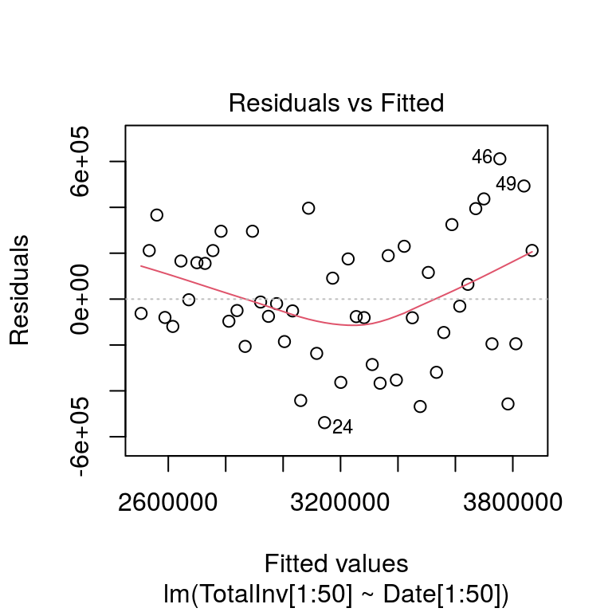

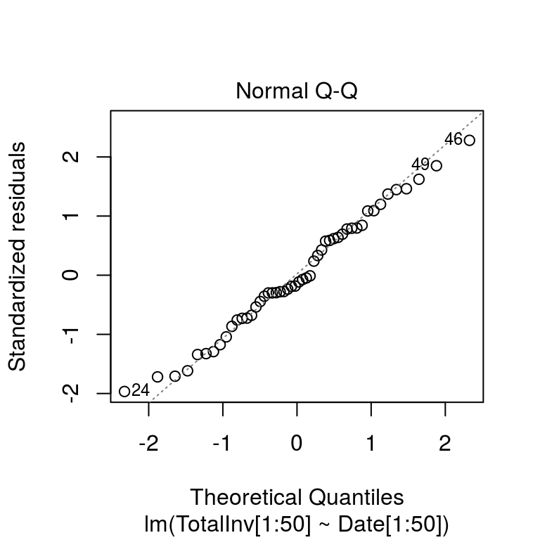

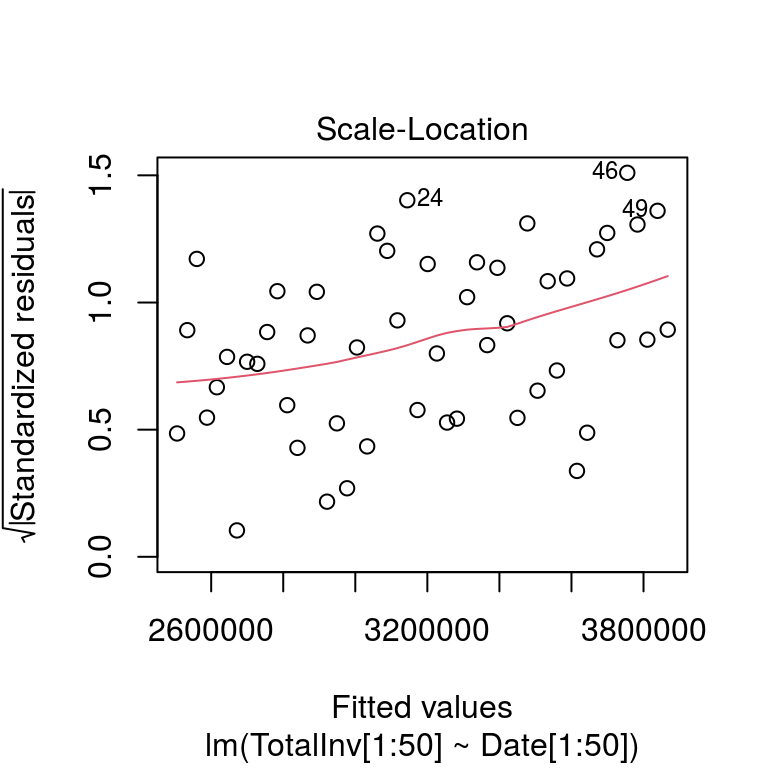

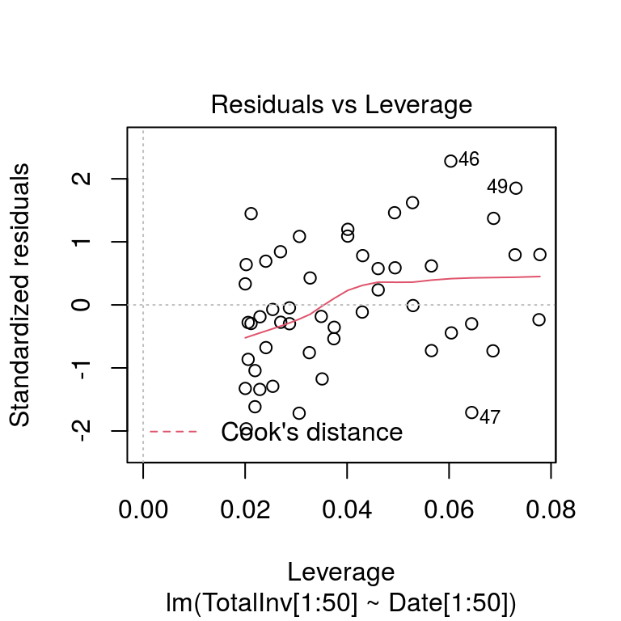

```r
mod5 <- lm(TotalInv[1:50] ~ Date[1:50], data = dataset)
plot(mod5)
```

R adjusted is 67.96%, which means there is another 32% of variance that is not explained by the model.

This model would not be sufficient to use to predict future sales.

```r
summary(mod5)
```

```
##
## Call:
## lm(formula = TotalInv[1:50] ~ Date[1:50], data = dataset)
##
## Residuals:
##     Min      1Q  Median      3Q     Max
## -538327 -192340  -40382  205895  611490
##
## Coefficients:
##               Estimate Std. Error t value Pr(>|t|)
## (Intercept) -1.283e+07  1.564e+06  -8.204 1.08e-10 ***
## Date[1:50]   9.128e+02  8.910e+01  10.244 1.14e-13 ***
## ---
## Signif. codes:
## 0 '***' 0.001 '**' 0.01 '*' 0.05 '.' 0.1 ' ' 1
##
## Residual standard error: 276600 on 48 degrees of freedom
## Multiple R-squared:  0.6862, Adjusted R-squared:  0.6796
## F-statistic: 104.9 on 1 and 48 DF,  p-value: 1.143e-13
```

```r
# predict(mod4, dataset)
```

# ARIMA for predicting Shipto Locations

On other hand, model that explains relationship between Sales and Shipto Locations can be assumed to be appropriate, since its adjusted R squared is 78%. To use it, the Shipto Locations need to be predicted also.  
ARIMA algorithm is chosen to forecast the Location count that will be used as independent variables in linear regression to predict future monthly sales.

Dataset consists of dates starting January 2017 until February 2020.

ARIMA(1,0,0)(0,1,0)[12] with drift is suggested by auto.arima().  
AIC=390.86

```r
ts2 <- ts(dataset$TotalUniqShipTos[13:50], frequency = 12, start = c(2017,
    1))
dataset_esf <- window(ts2, frequency = 12, start = c(2017, 1),
    end = c(2020, 2))
(arima1 <- auto.arima(dataset_esf, D = 1))
```

```
## Series: dataset_esf
## ARIMA(1,0,0)(0,1,0)[12] with drift
##
## Coefficients:
##          ar1    drift
##       0.3429  39.7430
## s.e.  0.1833   9.6711
##
## sigma^2 estimated as 169334:  log likelihood=-192.43
## AIC=390.86   AICc=391.95   BIC=394.63
```

Forecast of Locations count for the next 12 months look like following:

```r
f_cast <- forecast(arima1, 12)
f_cast
```

```
##          Point Forecast    Lo 80    Hi 80    Lo 95    Hi 95
## Mar 2020       6795.173 6267.812 7322.533 5988.644 7601.701
## Apr 2020       7218.661 6661.166 7776.156 6366.046 8071.276
## May 2020       6977.172 6416.241 7538.103 6119.302 7835.041
## Jun 2020       6869.118 6307.785 7430.452 6010.633 7727.604
## Jul 2020       7623.357 7061.976 8184.738 6764.799 8481.915
## Aug 2020       7614.410 7053.024 8175.797 6755.844 8472.977
## Sep 2020       7107.086 6545.699 7668.473 6248.519 7965.653
## Oct 2020       8609.974 8048.587 9171.361 7751.407 9468.542
## Nov 2020       6732.936 6171.549 7294.323 5874.369 7591.504
## Dec 2020       6921.923 6360.536 7483.310 6063.356 7780.491
## Jan 2021       7475.919 6914.532 8037.306 6617.351 8334.486
## Feb 2021       7006.917 6445.530 7568.304 6148.350 7865.485
```

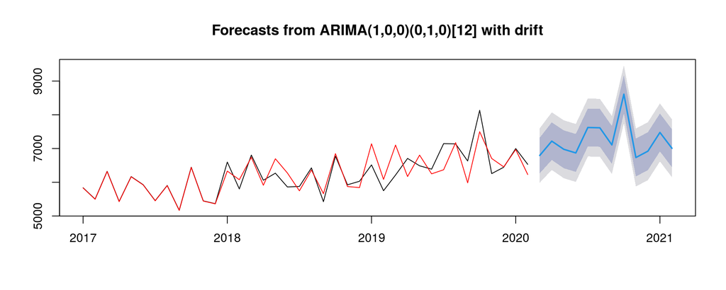

```r
plot(f_cast)
lines(fitted(arima1), col = "red")
```

Forecasted count of locations are fed into the linear regression model to predict monthly sales for the next 12 months.

Forecast of Sales for the next 12 months starting march of 2020 looks like following:

```r
predicted <- f_cast$mean
predict_sales <- c(0, 0, 0, 0, 0, 0, 0, 0, 0, 0, 0, 0)
for (i in (length(predicted):1)) {
    df_predict <- data.frame(TotalUniqShipTos = predicted[i])
    Pred2 <- predict(mod4, df_predict, interval = "predict")

    predict_sales[i] <- Pred2[1, 1]

}
data.frame(month = c(1:12), predict_sales)
```

| month | predict_sales |
| --- | --- |
| 1 | 3635314 |
| 2 | 3907889 |
| 3 | 3752456 |
| 4 | 3682908 |
| 5 | 4168369 |
| 6 | 4162610 |
| 7 | 3836074 |
| 8 | 4803398 |
| 9 | 3595256 |
| 10 | 3716896 |

[output cut: 2 more lines]